# Are developing country innovators hidden giants?

Innovation Strategy Explorer — insights

2026-04-26

## Citation, EV, and AV ranks at the docdb level

Collapse the app’s main database to one row per `docdb_family_id`, attach flags telling us whether the family is mapped to **China**, any **HIC**, or any **non-HIC country (excluding China)**, then rank docdbs (1 = highest) by:

- **Citation count** (`cit_count`) — number of times a docdb is cited by another docdb in the app database.
- **EV global** (`ev_global`) — Watson average global spillover.
- **AV global** (`av_global`) — Watson average global return.

Country-class flags are not mutually exclusive (a family can be mapped to e.g. both the US and China). For colouring the scatter we collapse to a single primary class with priority **China → HIC → non-HIC excl. China**.

```
## cited docdbs: 11,161,562   (HIC: 3,705,469, China: 7,592,453, non-HIC excl China: 117,403)
```

### Hidden-giant indices (citation rank vs value rank)

- `higx_ev = cit_rank − ev_rank`
- `higx_av = cit_rank − av_rank`

Both ranks have **1 = highest**, so a *negative* index means a docdb is more highly cited than its value rank would predict — a candidate “hidden giant”. A *positive* value means the opposite (high value, few citations).

| region_class | n | mean_higx_ev | median_higx_ev | p75_higx_ev | p90_higx_ev | p95_higx_ev |
| --- | --- | --- | --- | --- | --- | --- |
| China | 7,592,453 | -19.05 | -17.21 | 4.22 | 23.29 | 36.55 |
| HIC | 3,507,663 | -22.23 | -20.47 | 1.07 | 22.75 | 37.96 |
| non-HIC excl China | 61,446 | -21.71 | -19.7 | 0.74 | 20.62 | 35.65 |

```
## [1] 11161562
```

```
## [1] 11161562
```

### Country-class flag overlap

| is_hic | is_china | is_lmic_xcn | region_class | n | share |
| --- | --- | --- | --- | --- | --- |
| FALSE | TRUE | FALSE | China | 7,391,308 | 0.6622 |
| TRUE | FALSE | FALSE | HIC | 3,457,935 | 0.3098 |
| TRUE | TRUE | FALSE | China | 194,916 | 0.0175 |
| FALSE | FALSE | TRUE | non-HIC excl China | 61,446 | 0.0055 |
| TRUE | FALSE | TRUE | HIC | 49,728 | 0.0045 |
| FALSE | TRUE | TRUE | China | 3,339 | 0.0003 |
| TRUE | TRUE | TRUE | China | 2,890 | 0.0003 |

#### Granted families only

Same overlap table restricted to docdbs with at least one granted application — useful as a check on whether the flag distribution shifts when applications that never made it through examination are excluded.

| is_hic | is_china | is_lmic_xcn | region_class | n | share |
| --- | --- | --- | --- | --- | --- |
| FALSE | TRUE | FALSE | China | 4,158,066 | 0.6619 |
| TRUE | FALSE | FALSE | HIC | 1,972,930 | 0.3141 |
| TRUE | TRUE | FALSE | China | 97,450 | 0.0155 |
| FALSE | FALSE | TRUE | non-HIC excl China | 25,258 | 0.004 |
| TRUE | FALSE | TRUE | HIC | 25,155 | 0.004 |
| FALSE | TRUE | TRUE | China | 1,463 | 0.0002 |
| TRUE | TRUE | TRUE | China | 1,318 | 0.0002 |

#### `docdb_family_size` > 1

Same overlap table restricted to docdbs whose PATSTAT `docdb_family_size` is at least 2 (multi-application families). The eligible-family list is read from `.bigdata/fam_size_min2.parquet`, the BigQuery cache that `01-build-app-parquets.R` produces when the build-time family-size filter is enabled.

| is_hic | is_china | is_lmic_xcn | region_class | n | share |
| --- | --- | --- | --- | --- | --- |
| TRUE | FALSE | FALSE | HIC | 1,462,228 | 0.7857 |
| FALSE | TRUE | FALSE | China | 254,491 | 0.1368 |
| TRUE | TRUE | FALSE | China | 99,647 | 0.0535 |
| FALSE | FALSE | TRUE | non-HIC excl China | 21,664 | 0.0116 |
| TRUE | FALSE | TRUE | HIC | 21,341 | 0.0115 |
| TRUE | TRUE | TRUE | China | 1,333 | 0.0007 |
| FALSE | TRUE | TRUE | China | 286 | 0.0002 |

### Regressions on country-class flags

| outcome | term | estimate | std.error | statistic | p.value | conf.low | conf.high |
| --- | --- | --- | --- | --- | --- | --- | --- |
| higx_ev | (Intercept) | -22.259 | 0.019 | -1,183.68 | 0 | -22.296 | -22.222 |
| higx_ev | is_chinaTRUE | 3.209 | 0.023 | 141.48 | 0 | 3.165 | 3.253 |
| higx_ev | is_lmic_xcnTRUE | 1.124 | 0.104 | 10.84 | 0 | 0.921 | 1.327 |

```
## n (mapped docdbs): 11,161,562   |   R^2 (higx_ev): 0.0018
```

#### Granted families only

Re-run on the subset where `granted = TRUE` (the docdb has at least one granted application). This filters out applications that never made it through examination, which can carry citation patterns very different from granted patents.

| outcome | term | estimate | std.error | statistic | p.value | conf.low | conf.high |
| --- | --- | --- | --- | --- | --- | --- | --- |
| higx_ev | (Intercept) | -21.383 | 0.025 | -872.75 | 0 | -21.431 | -21.335 |
| higx_ev | is_chinaTRUE | -1.154 | 0.03 | -38.94 | 0 | -1.212 | -1.096 |
| higx_ev | is_lmic_xcnTRUE | 0.765 | 0.151 | 5.06 | 0 | 0.469 | 1.061 |

```
## n (granted, mapped docdbs): 6,281,640   |   R^2 (higx_ev): 0.0003
```

#### `docdb_family_size` > 1

Re-run on the multi-application subset (PATSTAT `docdb_family_size >= 2`), using the same `.bigdata/fam_size_min2.parquet` cache that the overlap table above reads.

| outcome | term | estimate | std.error | statistic | p.value | conf.low | conf.high |
| --- | --- | --- | --- | --- | --- | --- | --- |
| higx_ev | (Intercept) | -26.877 | 0.027 | -1,000.86 | 0 | -26.93 | -26.825 |
| higx_ev | is_chinaTRUE | 11.487 | 0.061 | 189.29 | 0 | 11.368 | 11.606 |
| higx_ev | is_lmic_xcnTRUE | 4.532 | 0.156 | 29.05 | 0 | 4.226 | 4.837 |

```
n (fam_size>=2, mapped docdbs): 1,860,990   |   R^2 (higx_ev): 0.0190
```

### Coefficient comparison across specifications

Stacks the three sub-samples (all mapped docdbs, granted only, `fam_size >= 2`) into one figure so the coefficient on each country-class flag is comparable across them. Bars are coefficient point estimates with 95 % confidence intervals; the dashed zero line is the no-effect reference.

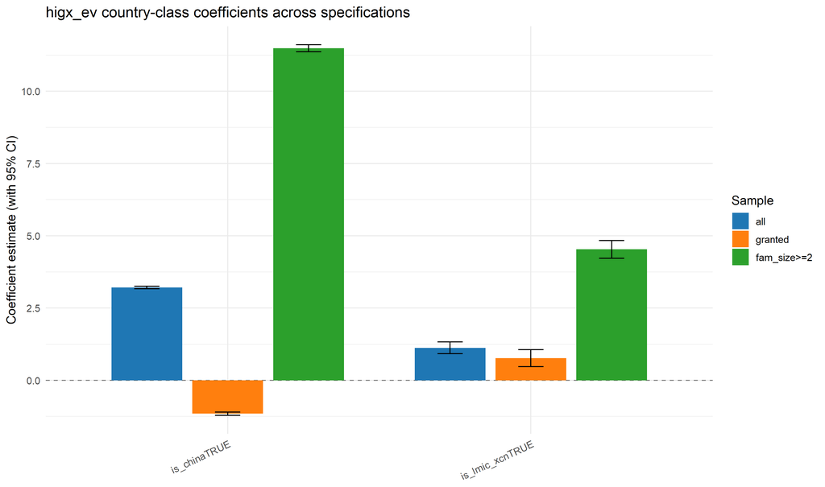

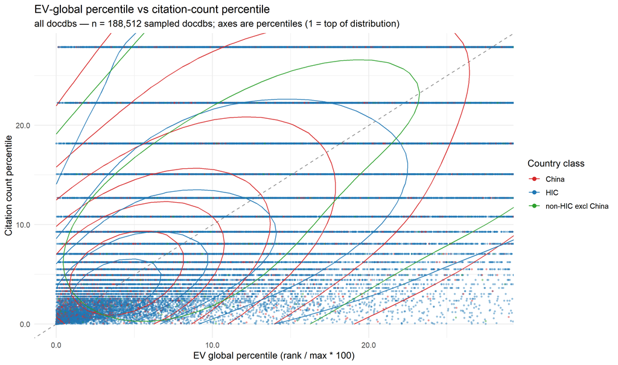

#### Granted families only

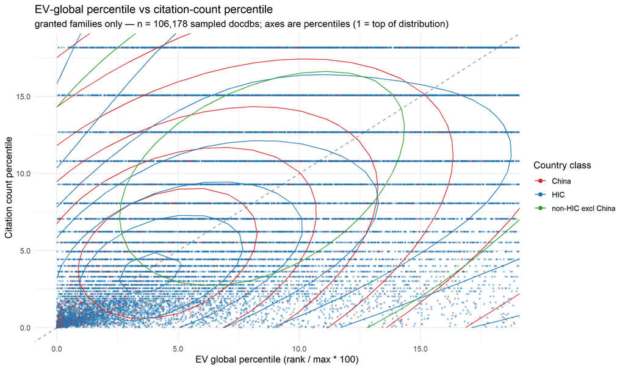

#### `docdb_family_size` > 1

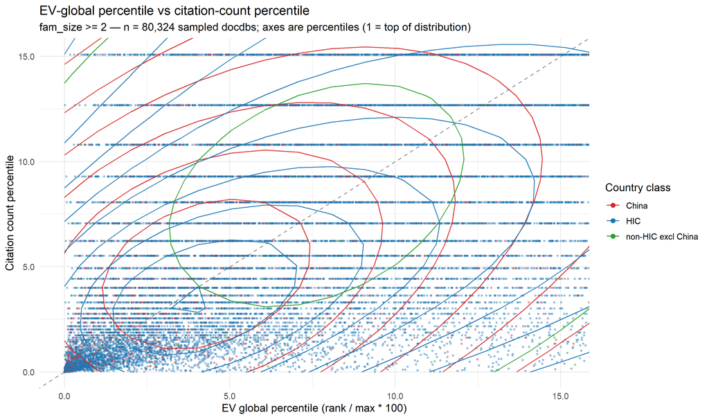

### Quartile grid: share by country class

Bin both axes into four equal-width percentile bins (0-25, 25-50, 50-75, 75-100) and assign every docdb to one of the resulting 4 x 4 = 16 cells. Within each country-class group (China / HIC / non-HIC excl China) compute the share of the group’s docdbs falling in each cell. Each cell shows three coloured dots — one per group — with the dot’s size proportional to that group’s share of its own population in that cell. Because we collapse to a 16-cell summary, this can be computed on the full data, no Bernoulli sample needed.

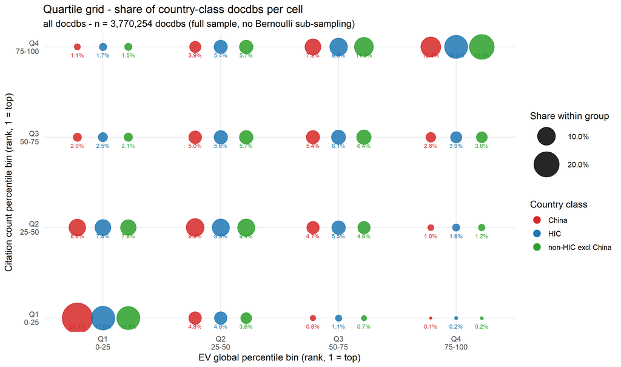

#### Granted families only

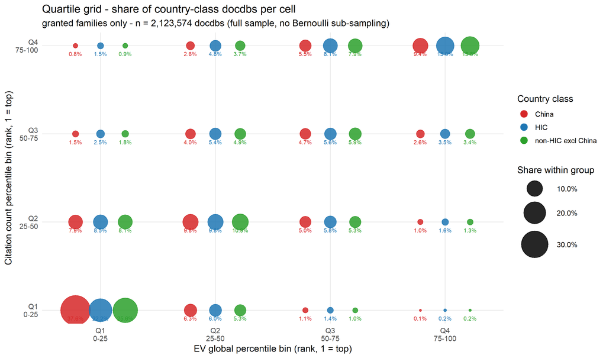

#### `docdb_family_size` > 1

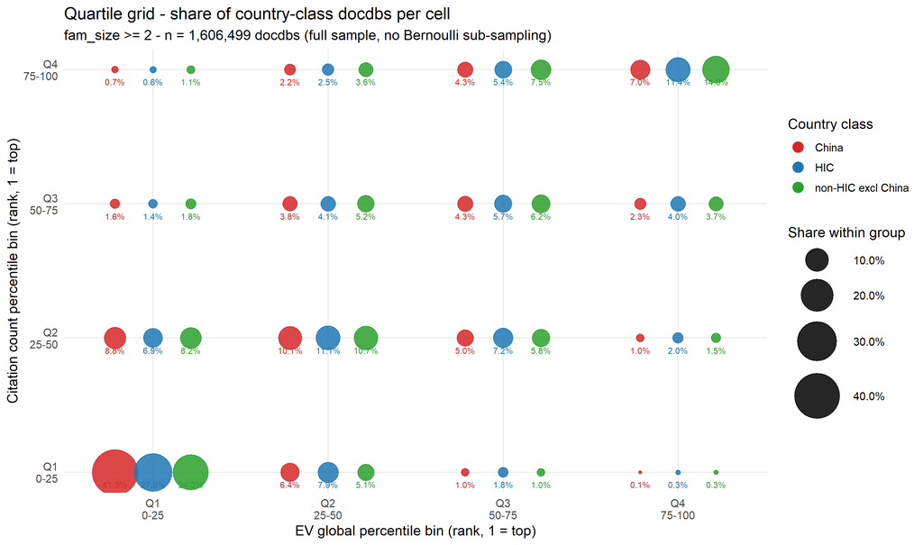

### `higx_ev` distribution by country class

Each diagram is a single side-by-side boxplot — one box per country class. Three diagrams cover the three samples (all / granted / `fam_size >= 2`). Outlier dots are suppressed because each subset has millions of rows; the median, IQR, and whiskers carry the same information.

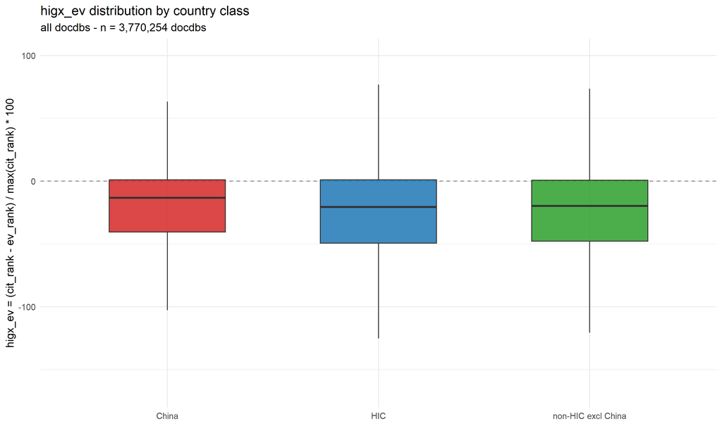

#### Granted families only

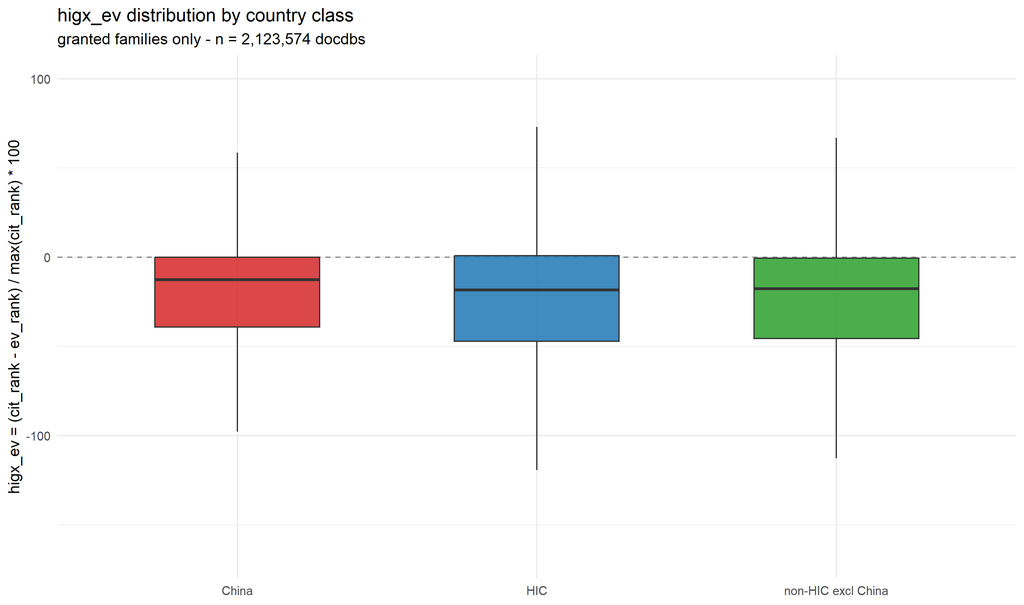

#### `docdb_family_size` > 1

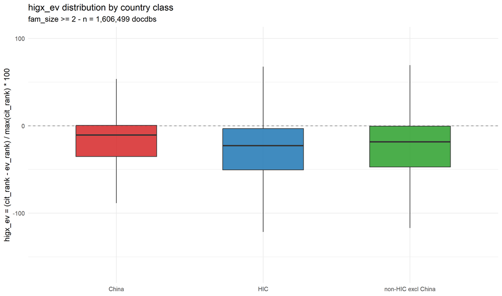

### `higx_ev` density by country class

Same data, same exclusions, but now as overlaid kernel-density curves so the full shape of each group’s distribution is visible — modes, skew, heavy tails — not just the five-number summary the boxplots show. Each group is normalised to integrate to 1, so the heights are directly comparable regardless of group size.

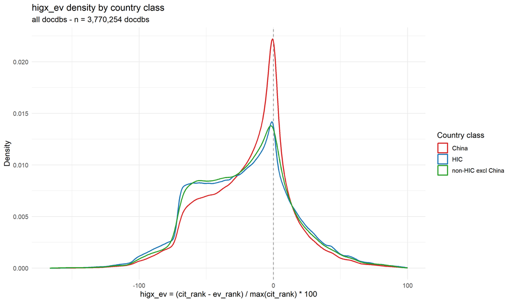

#### Granted families only

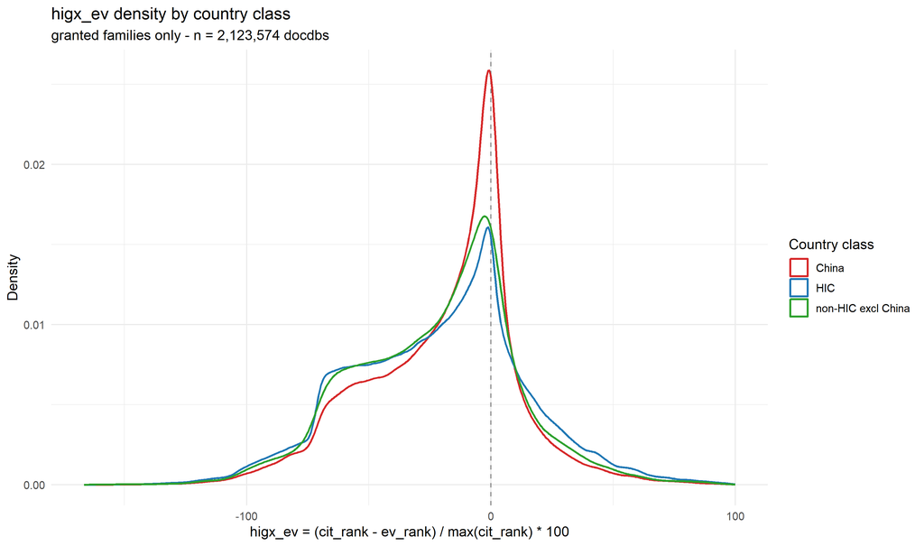

#### `docdb_family_size` > 1

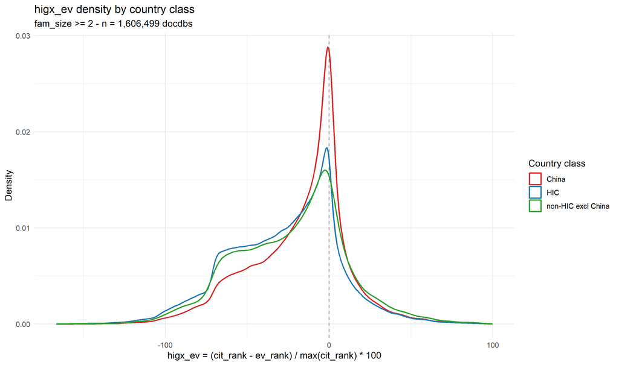

### `higx_ev` cumulative distribution by country class

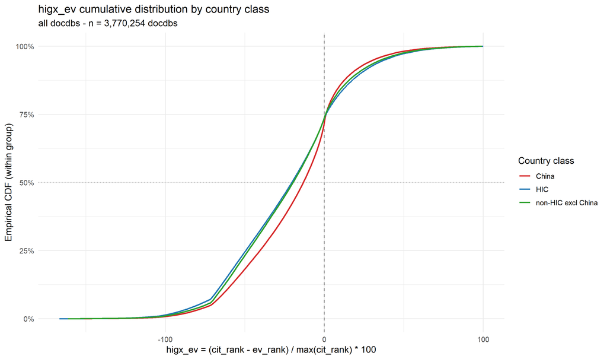

#### Granted families only

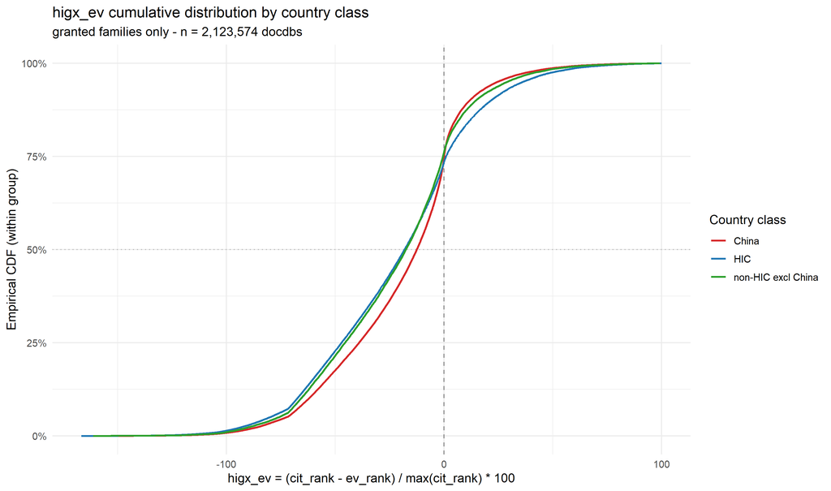

#### `docdb_family_size` > 1

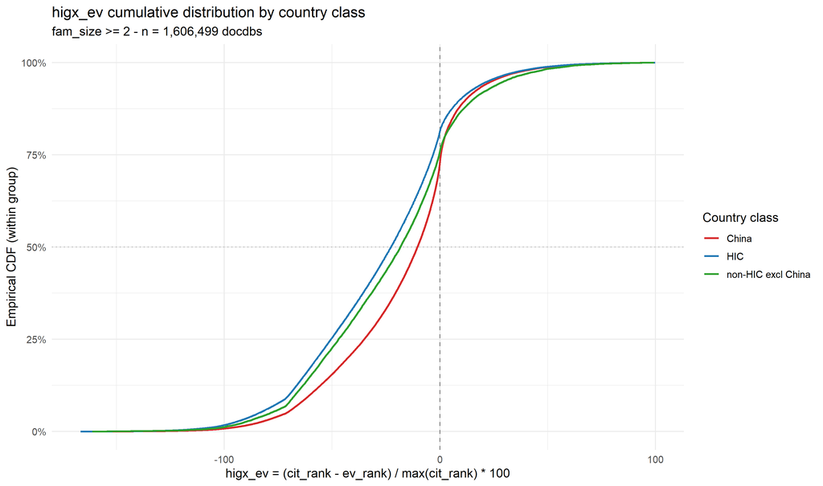